# Novel Geomorph Terrain Analysis

Matthew Ross

6/19/2020

# Datasets and descriptions

This portion of our novel geomorphology project is focused on examining shifts in landscapes after human interventions, and answering the question “Do people have consistent impacts on geomorphic features? If so what are these, and why do they happen?” We wanted to keep this analysis open ended across landscape types, so we have four landscapes for analysis. 1) Wetlands impacted by ditching (or not). 2) Piedmont watersheds impacted by historical agriculture and erosion (or mostly not). 3) Appalachian watersheds that were mined or not, and 4) Coastal watersheds impacted by canals (or reconstructed without canals)

## Piedmont watersheds

### Pre-processing

The piedmont data comes as one overarching DEM, which needs to be broken down into watersheds. We do that here:

```r
#File pointers
o_dem <- 'data/in/calhoun/CalhounBigDEM.tif'
c_dem <- 'data/in/calhoun/CalhounDEM.tif'
```

```r
#Reproject pour points
st_read('data/in/calhoun/CalhounPourpoints.shp') %>%
  st_transform(crs = st_crs(raster(c_dem))) %>%
  st_write('data/in/calhoun/CalhounProjPoints.shp')

#Read in reprojected pourpoints
proj <- st_read('data/in/calhoun/CalhounProjPoints.shp') %>%
  #buffer by 500m (iterated with watershed sizes)
  st_buffer(500)

#Trim up raster (which is enormous) by buffering pour poitns
smaller <- terra::crop(rast(o_dem),proj)


#Save smaller raster (hope it's not too small. Ask John)
writeRaster(smaller,c_dem, overwrite = T)


#Fill single cell pits (for hydrologic correctness)
wbt_fill_single_cell_pits(c_dem,'data/out/calhoun/breach2.tif')

#Breach depressions (better option that pit filling according to whitebox docu
#mentation) The flat_increment bit was tricky for me and needed to be tuned.
wbt_breach_depressions(c_dem,'data/out/calhoun/breached.tif',flat_increment=.1)


#D8 pointer (what is a pointer? a flow direction grid? probably)
wbt_d8_pointer('data/out/calhoun/breached.tif','data/out/calhoun/d8_pntr.tif')

#D8 flow
wbt_d8_flow_accumulation('data/out/calhoun/breached.tif','data/out/calhoun/d8_flow.tif',out_type='catchment area')


#snap_points
wbt_snap_pour_points('data/in/calhoun/CalhounProjPoints.shp','data/out/calhoun/d8_flow.tif',
                 'data/out/calhoun/snapped_sites.shp',20)


#Watershed delineation as "whole watersheds'
wbt_unnest_basins('data/out/calhoun/d8_pntr.tif',
                  'data/out/calhoun/snapped_sites.shp',
                  'data/out/calhoun/cal_sheds.tif')
```

## Check calhoun watershed snaps.

```r
snaps <- st_read('data/out/calhoun/snapped_sites.shp')
```

```
FALSE Reading layer `snapped_sites' from data source `C:\Users\mrvr\Dropbox\CSU\CSU_Papers\Novel-Geomorph\data\out\calhoun\snapped_sites.shp' using driver `ESRI Shapefile'
FALSE Simple feature collection with 4 features and 1 field
FALSE geometry type:  POINT
FALSE dimension:      XY
FALSE bbox:           xmin: 436092 ymin: 3828857 xmax: 438181 ymax: 3830518
FALSE CRS:            unknown
```

```r
pours <- st_read('data/in/calhoun/CalhounProjPoints.shp')
```

```
FALSE Reading layer `CalhounProjPoints' from data source `C:\Users\mrvr\Dropbox\CSU\CSU_Papers\Novel-Geomorph\data\in\calhoun\CalhounProjPoints.shp' using driver `ESRI Shapefile'
FALSE Simple feature collection with 4 features and 1 field
FALSE geometry type:  POINT
FALSE dimension:      XY
FALSE bbox:           xmin: 436101.6 ymin: 3828847 xmax: 438175.8 ymax: 3830508
FALSE CRS:            unknown
```

```r
mapview(snaps) | mapview(pours)
```

[interactive chart not shown]

## Split watersheds into individual sheds

```r
#Same order as read in (probably?)
sheds <- rast('data/out/calhoun/cal_sheds_1.tif')

#split sheds into subunits
shed_splitter <- function(index){
  #Slow because domain is big
  single_shed = mask(sheds,sheds != index, maskvalue = 1) %>%
    trim(.)

  #Fast af, because crop and terra is awesome.
  elev_shed <- crop(rast(c_dem),single_shed) %>%
    terra::mask(.,single_shed) %>%
    trim(.)


  #Write it out with assumed shed name. Can fix if not in order from snap
  terra::writeRaster(elev_shed,
                     filename = paste0('data/in/calhoun/',
                                      pours$wshd[index],
                                      '.tif'),
                     overwrite = T)
}

walk(1:4,shed_splitter)
```

## MTM Data prep

OMG my old workflowss are such a mess. Took me forever to find this data. But I eventually found clean watershed elevation outlines for pre and post mining watersheds in the mud river.

## Whitebox super function

Build a function that does ~ 10 relevant analyses for a given DEM. Use Anna’s sites as example.

- Add Ryan Emmanuel DEMS from paper
- Get Mallard

```r
#Get the raw tifs that ends with ($) .tif

#Make a table for simpler names
#I'm ashamed of how manual this is. Was just easier.
dem_table <- tibble(files=c(list.files('data/in/coastal',
                                     pattern = '.tif$', full.names=T),
                            'data/in/calhoun/Bowl.tif',
                            'data/in/calhoun/WS2.tif',
                            'data/in/calhoun/WS3.tif',
                            'data/in/calhoun/WS4.tif',
                            list.files('data/in/mtm',full.names=T)),
                    og_names = c(list.files('data/in/coastal',
                                          pattern = '.tif$'),
                                 'Bowl.tif',
                                 'WS2.tif',
                                 'WS3.tif',
                                 'WS4.tif',
                                 list.files('data/in/mtm')),
                    simple_names = c(
                                     'NY_ditched_a',
                                     'NY_ditched_b',
                                     'NY_naturalsih',
                                     'SC_natural_a',
                                     'SC_natural_b',
                                     'Bowl',
                                     'WS1',
                                     'Ws2',
                                     'WS3',
                                     list.files('data/in/mtm') %>%
                                       gsub('.tif','',.)),
                    treatment = c('novel','novel',
                                  'natural','natural','natural','natural',
                                  'novel','novel','novel',
                                  rep(c('novel','natural'),times=7)))

# In retrospect this is kind of wasteful. WBT is fast AF and I should
#probably just wrap the high level analyses in here.
#But whatever.
super_whitebox <- function(files,og_names,simple_names,treatment){


  paster <- function(post = 'wbt_function'){
    paste0(out_folder,simple_names,post,'.tif')
  }

  #Name output folder
  out_folder <- gsub(og_names,'',files) %>%
    gsub('in','out',.)

  #Calculate ruggedness index
  wbt_ruggedness_index(dem = files,
                       output = paster('_ruggedness'))

  #Calculate releative elevation
  wbt_elev_relative_to_min_max(dem = files,
                               output = paster('_rel_elev'))

  #Edge density
  wbt_edge_density(files,
                   output = paster('_edge_density'),
                   norm_diff = 5)

  #surface area ratio
  wbt_surface_area_ratio(files,
                         output = paster('_surface_area'))


  #Breach depressions (better option that pit filling according to whitebox docu
  #mentation) The flat_increment bit was tricky for me and needed to be tuned.
  wbt_breach_depressions(files,
                         output = paster('_breach'),
                         flat_increment=.1)


  #D8 flow
  wbt_d8_flow_accumulation(paster('_breach'),
                           paster('_d8_faa'),
                           out_type = 'catchment area')

}

pwalk(dem_table,super_whitebox)
```

## Comparing other metrics (by hand… womp womp)

```r
reader <- function(r){
  v <- as.vector(rast(r)) %>% na.omit()
  place <- gsub(paste0('_',analysis,'.tif'),'',r)

  split_strings <- str_split_fixed(r,'/',n=4)


  table <- tibble(value = v,
                  name = analysis,
                  domain = split_strings[,3],
                  simple_names = gsub(paste0('_',analysis,'.tif'),'',split_strings[,4]))
}


comp_function <- function(analysis = 'ruggedness'){

  files <- list.files('data/out',
                      pattern = analysis,
                      recursive = T,
                      full.names = T)

    reader <- function(r){
      v <- as.vector(rast(r)) %>% na.omit()
      v[v < -30] <- NA
      place <- gsub(paste0('_',analysis,'.tif'),'',r)

      split_strings <- str_split_fixed(r,'/',n=4)


      table <- tibble(value = v,
                      name = analysis,
                      domain = split_strings[,3],
                      simple_names = gsub(paste0('_',analysis,'.tif'),
                                          '',split_strings[,4]))
  }

  t <- map_dfr(files,reader) %>%
    inner_join(dem_table)

  # Way overkill to plot all data, but whatever.
  gplot <- ggplot(t,aes(value, color = treatment, group = simple_names)) +
    geom_density() +
    facet_wrap(~domain,scales = 'free', ncol = 1 ) +
    ggthemes::theme_few() +
    ggtitle(analysis) +
    scale_color_manual(name = '',values = c('green3','black')) +
    theme(legend.position = c('top'), legend.direction = 'horizontal')


  summary <- t %>%
    group_by(domain,treatment,simple_names) %>%
    summarize(median = median(value),
              mean = mean(value),
              min = min(value),
              max = max(value)) %>%
    mutate_if(is.numeric,round,2)


  return(list(gplot,summary))
}
```

### Ruggedness

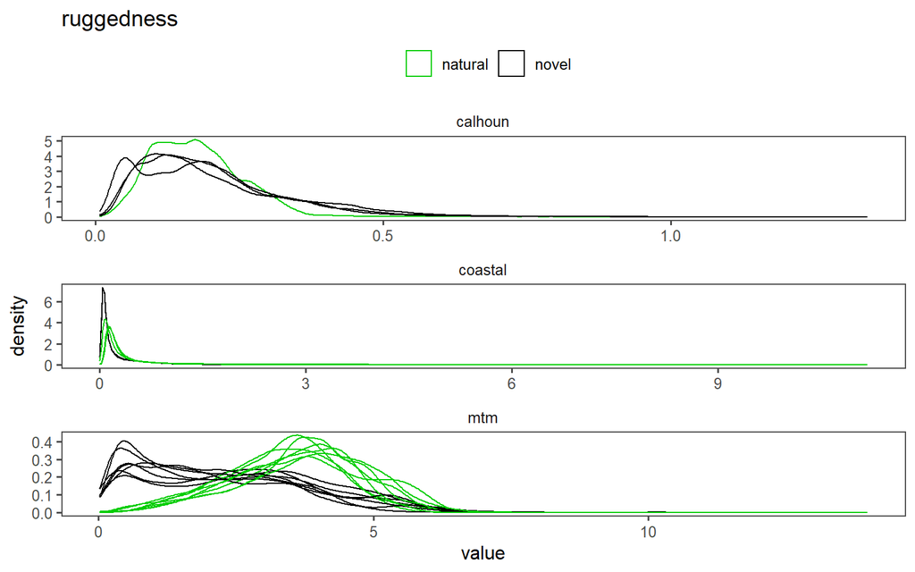

```r
rug <- comp_function(analysis = 'ruggedness')

rug[[1]]
```

```r
knitr::kable(rug[[2]])
```

| domain | treatment | simple_names | median | mean | min | max |
| --- | --- | --- | --- | --- | --- | --- |
| calhoun | natural | Bowl | 0.17 | 0.18 | 0.01 | 0.90 |
| calhoun | novel | WS1 | 0.18 | 0.20 | 0.01 | 1.34 |
| calhoun | novel | Ws2 | 0.17 | 0.21 | 0.01 | 1.26 |
| calhoun | novel | WS3 | 0.18 | 0.19 | 0.01 | 1.00 |
| coastal | natural | NY_naturalsih | 0.16 | 0.26 | 0.01 | 2.61 |
| coastal | natural | SC_natural_a | 0.24 | 0.48 | 0.02 | 11.17 |
| coastal | natural | SC_natural_b | 0.22 | 0.50 | 0.01 | 9.77 |
| coastal | novel | NY_ditched_a | 0.10 | 0.21 | 0.00 | 3.06 |
| coastal | novel | NY_ditched_b | 0.10 | 0.22 | 0.01 | 3.26 |
| mtm | natural | ballard_pre | 3.78 | 3.68 | 0.03 | 6.43 |
| mtm | natural | horse_pre | 3.38 | 3.36 | 0.42 | 7.33 |
| mtm | natural | lb_pre | 3.41 | 3.30 | 0.27 | 6.09 |
| mtm | natural | sally_pre | 3.74 | 3.74 | 0.42 | 6.73 |
| mtm | natural | sally2_pre | 3.79 | 3.71 | 0.39 | 6.84 |
| mtm | natural | stanley_pre | 3.93 | 3.78 | 0.03 | 8.07 |
| mtm | natural | sugar_pre | 3.55 | 3.40 | 0.22 | 6.09 |
| mtm | novel | ballard_post | 2.47 | 2.49 | 0.02 | 7.63 |
| mtm | novel | horse_post | 2.37 | 2.49 | 0.02 | 13.98 |
| mtm | novel | lb_post | 2.77 | 2.73 | 0.04 | 8.09 |
| mtm | novel | sally_post | 1.98 | 2.34 | 0.06 | 6.72 |
| mtm | novel | sally2_post | 2.04 | 2.22 | 0.06 | 6.97 |
| mtm | novel | stanley_post | 1.85 | 2.11 | 0.02 | 8.74 |
| mtm | novel | sugar_post | 1.72 | 1.90 | 0.03 | 6.93 |

### Edge density

Truly don’t know what this means

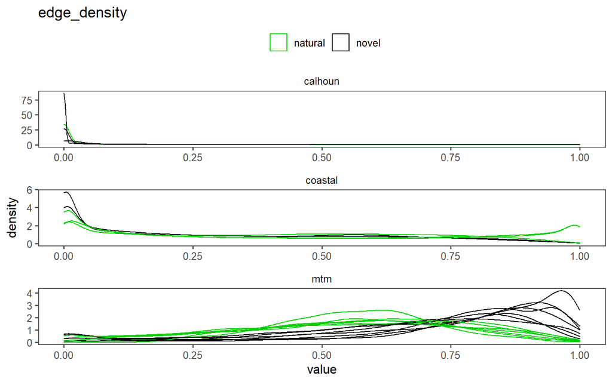

```r
edge_dens <- comp_function('edge_density')

edge_dens[[1]]
```

### Elevation

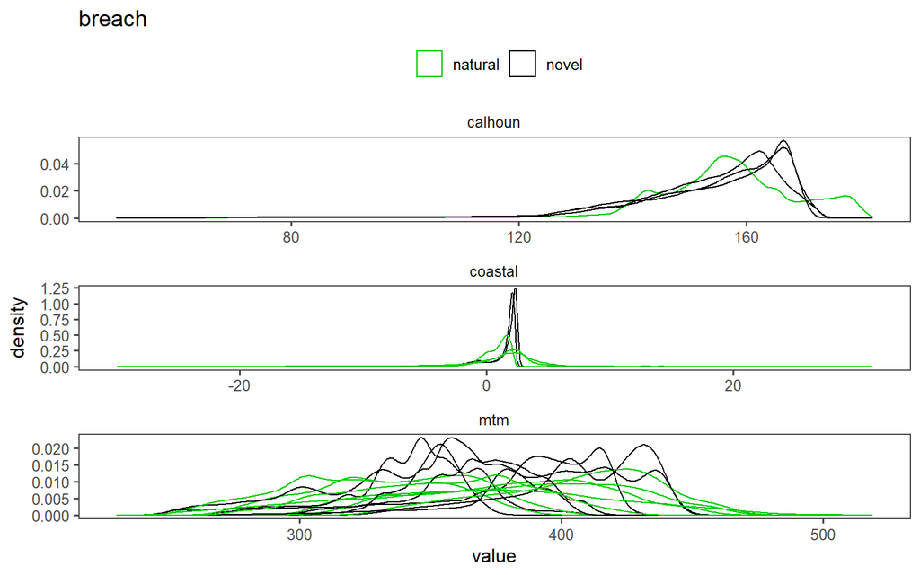

```r
rel_elev <- comp_function('breach')

rel_elev[[1]]
```

### FAA

No clue how to interpret in wetlands. Probably deeply flawed

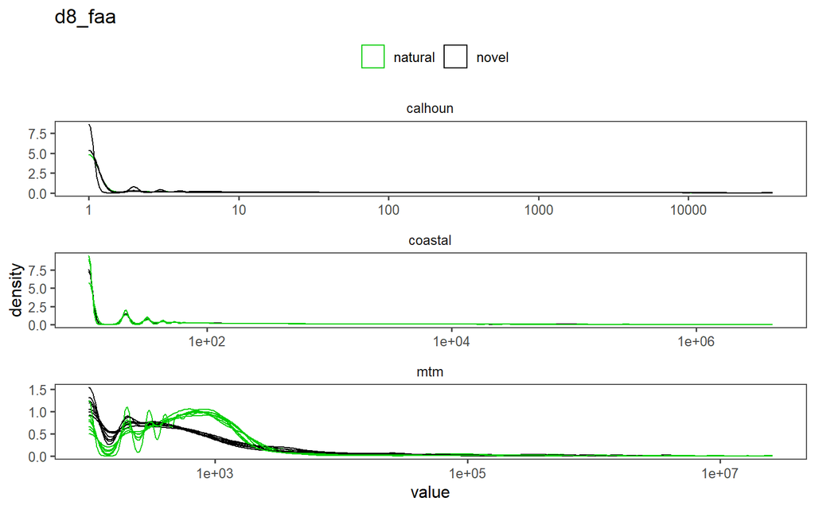

```r
faa <- comp_function('d8_faa')

faa[[1]] +
  scale_x_log10()
```

### Surface area

Like edge density. Some kind of relative roughness?

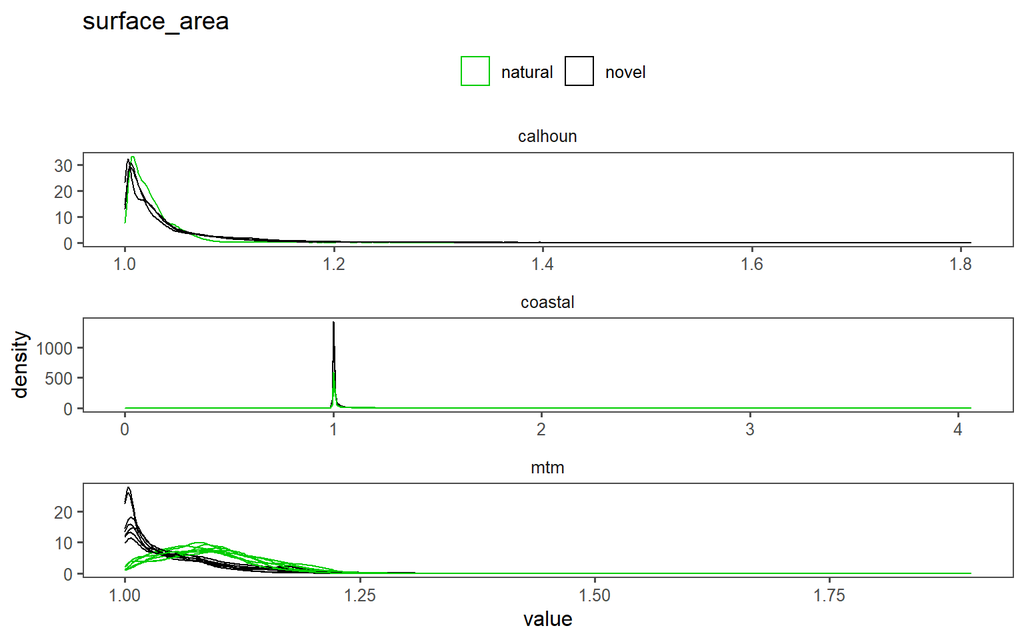

```r
sa <- comp_function('surface_area')

sa[[1]]
```

### Hypsometry

This requires a different function.

#### Raw Elevation hypsometry

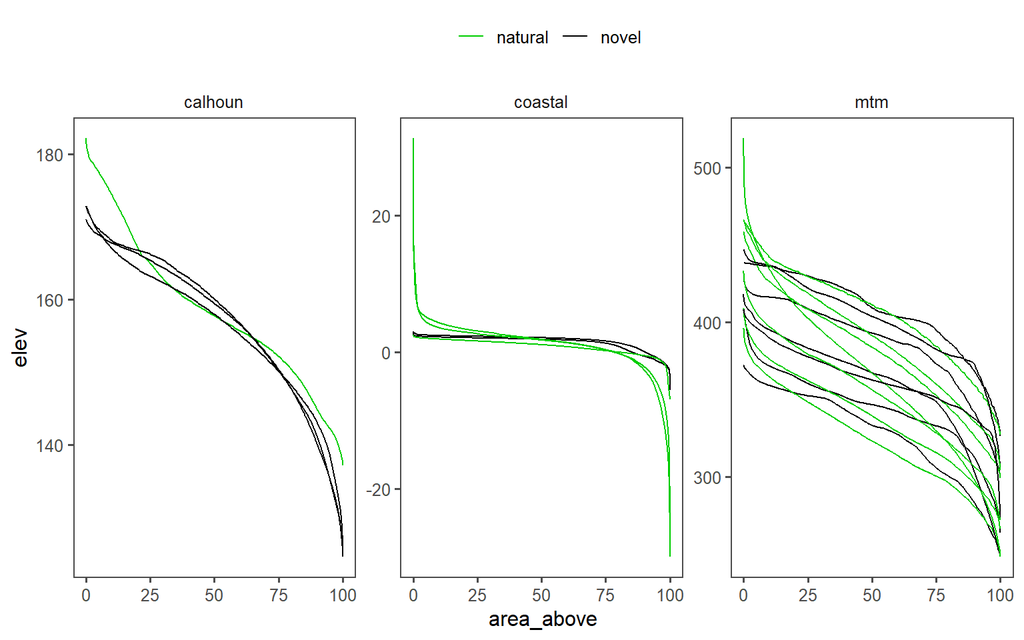

```r
hyp_reader <- function(files,og_names,simple_names,treatment){
    v <- as.vector(rast(files)) %>% na.omit() %>%
      round(.,1)

    unique_e <- unique(v)


    e.table <- tibble(elev = v) %>%
      mutate(e_bins = cut(elev,breaks=c(-Inf,unique_e,Inf))) %>%
      group_by(e_bins) %>%
      summarize(count = n(),
                freq = 100*count/length(v),
                elev = first(elev) %>% na.omit(.)) %>%
      mutate(rel_elev = 100*((elev - min(elev))/(max(elev)-min(elev)))) %>%
      arrange(-elev) %>%
      mutate(area_above = cumsum(freq),
              simple_names = simple_names,
              treatment = treatment,
             domain = str_split_fixed(files,'/',4)[,3])


}

hyp_data <- pmap_dfr(dem_table,hyp_reader)


ggplot(hyp_data,aes(x=area_above, y = elev, color = treatment, group = simple_names)) +
  geom_line() +
  facet_wrap(~domain,nrow = 1, scales = 'free') +
  ggthemes::theme_few() +
  scale_color_manual(name = '',values = c('green3','black')) +
  theme(legend.position = c('top'), legend.direction = 'horizontal')
```

#### Relative elevation hyp

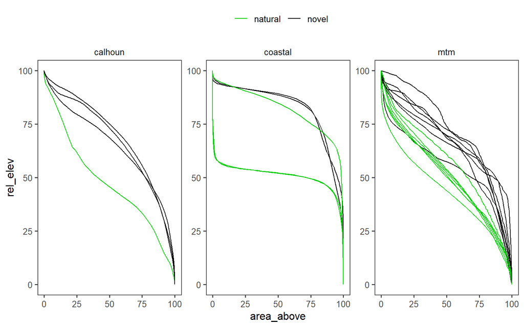

```r
ggplot(hyp_data,aes(x=area_above, y = rel_elev, color = treatment, group = simple_names)) +
  geom_line() +
  facet_wrap(~domain,nrow = 1, scales = 'free') +
  ggthemes::theme_few() +
  scale_color_manual(name = '',values = c('green3','black')) +
  theme(legend.position = c('top'), legend.direction = 'horizontal')
```

## Abandoned code that might be useful someday

```r
# #Transform all coastal to 2163 projection
# transformer <- function(files,og_names,simple_names){
#
#   #I don't know how to define this outside of the
#   #function without breaking the pmap functionality
#   # which is somewhat like a with() call here.
#   paster <- function(post = 'wbt_function'){
#     paste0(out_folder,simple_names,post,'.tif')
#   }
#
#   orig_proj <- rast(files)
#
#     #Name output folder
#   out_folder <- gsub(og_names,'',files) %>%
#     gsub('in','out',.)
#
#
#   reproj <- project(orig_proj,'+proj=laea +lat_0=45 +lon_0=-100 +x_0=0 +y_0=0 +a=6370997 +b=6370997 +units=m +no_defs') %>%
#     clamp(., lower = -15, upper = 15, values = NA)
#
#
#   terra::writeRaster(reproj,paster('_2163'),overwrite = T)
# }
#
#
# # I think I finally understand pmap on dfs
# # But this is actually a pwalk situation (no direct output, only side
# # effects (as in projecting and saving reprojected rasters))
# #Pwalk requires that all column names be options in the call
# #Makes sense? I guess?
# pwalk(dem_table,transformer)
```